# 통계 방법론Ⅱ - 탐색적 데이터 분석

응용통계학과 이준혁

2023-06-10(토)

# Ch9. 중앙값 정제(Median Polish)

## 9.1. 중앙값 정제의 이해

**중앙값 정제(median polish)**는 서로 다른 2개의 상황 하에서 관찰된 반응값을 대상으로 각 상활별 효과(effects)와 나머지 잔차(residuals)로 분해하여 데이터의 해석을 돕는 방법이다.

## 9.2. 1991년 부터 2020년까지의 지역별 평균 기온(monthly.1991.2020.csv) 분석

monthly.1991.2020은 국내 219개 위치(location)에서 월별 평균 기온(°C)을 조사한 것이다. 각 위치별로 시작 일자는 서로 다르지만, 종료일은 2020년 12월로 동일하다.

### 9.2.1. 데이터 불러오기

```r
monthly <- read.csv(paste0(data_path, "monthly.1991.2020.csv"))
head(monthly)
```

```
##    no location V1월 V2월 V3월 V4월 V5월 V6월 V7월 X8월 V9월 V10월 V11월 V12월
## 1  90     속초  0.1  1.9  6.3 11.9 16.3 19.8 23.4 24.1 20.1  15.1   8.8   2.5
## 2  95     철원 -5.7 -2.3  3.7 10.5 16.6 21.1 23.8 24.0 18.9  11.8   4.3  -3.2
## 3  98   동두천 -3.8 -0.8  5.0 11.6 17.4 21.8 24.3 24.9 20.1  13.1   5.7  -1.9
## 4  99     파주 -4.6 -1.3  4.4 10.8 16.8 21.4 24.2 24.9 19.9  12.6   5.2  -2.6
## 5 100   대관령 -6.9 -4.6  0.4  7.0 12.5 16.2 19.6 19.7 14.6   8.8   2.3  -4.5
## 6 101     춘천 -4.1 -1.0  5.0 11.7 17.6 22.2 24.9 25.0 19.8  12.7   5.3  -2.0
```

### 9.2.2. 데이터의 구조 확인

```r
str(monthly)
```

```
## 'data.frame':    219 obs. of  14 variables:
##  $ no      : int  90 95 98 99 100 101 102 105 106 108 ...
##  $ location: chr  "속초" "철원" "동두천" "파주" ...
##  $ V1월    : num  0.1 -5.7 -3.8 -4.6 -6.9 -4.1 -1.3 0.9 1.1 -1.9 ...
##  $ V2월    : num  1.9 -2.3 -0.8 -1.3 -4.6 -1 0 2.7 2.8 0.7 ...
##  $ V3월    : num  6.3 3.7 5 4.4 0.4 5 3.8 7 6.8 6.1 ...
##  $ V4월    : num  11.9 10.5 11.6 10.8 7 11.7 9.1 13.1 12.2 12.6 ...
##  $ V5월    : num  16.3 16.6 17.4 16.8 12.5 17.6 14.5 17.9 16.6 18.2 ...
##  $ V6월    : num  19.8 21.1 21.8 21.4 16.2 22.2 19 21.3 19.6 22.7 ...
##  $ V7월    : num  23.4 23.8 24.3 24.2 19.6 24.9 22.3 24.7 23.2 25.3 ...
##  $ X8월    : num  24.1 24 24.9 24.9 19.7 25 23.8 25 24.1 26.1 ...
##  $ V9월    : num  20.1 18.9 20.1 19.9 14.6 19.8 20.1 20.5 19.8 21.6 ...
##  $ V10월   : num  15.1 11.8 13.1 12.6 8.8 12.7 14.7 15.6 15.1 15 ...
##  $ V11월   : num  8.8 4.3 5.7 5.2 2.3 5.3 7.9 9.5 9.3 7.5 ...
##  $ V12월   : num  2.5 -3.2 -1.9 -2.6 -4.5 -2 1.2 3.3 3.4 0.2 ...
```

```r
na_count(monthly)
```

```
##       no location     V1월     V2월     V3월     V4월     V5월     V6월
##        0        0        0        0        0        0        0        0
##     V7월     X8월     V9월    V10월    V11월    V12월
##        0        0        0        0        0        0
```

### 9.2.3. 데이터 구조 정리

```r
atemp <- data.frame(monthly[, -c(1,2)])
row.names(atemp) <- monthly$location
head(atemp)
```

```
##        V1월 V2월 V3월 V4월 V5월 V6월 V7월 X8월 V9월 V10월 V11월 V12월
## 속초    0.1  1.9  6.3 11.9 16.3 19.8 23.4 24.1 20.1  15.1   8.8   2.5
## 철원   -5.7 -2.3  3.7 10.5 16.6 21.1 23.8 24.0 18.9  11.8   4.3  -3.2
## 동두천 -3.8 -0.8  5.0 11.6 17.4 21.8 24.3 24.9 20.1  13.1   5.7  -1.9
## 파주   -4.6 -1.3  4.4 10.8 16.8 21.4 24.2 24.9 19.9  12.6   5.2  -2.6
## 대관령 -6.9 -4.6  0.4  7.0 12.5 16.2 19.6 19.7 14.6   8.8   2.3  -4.5
## 춘천   -4.1 -1.0  5.0 11.7 17.6 22.2 24.9 25.0 19.8  12.7   5.3  -2.0
```

### 9.2.4. 중앙값 정제

```r
ma.fit <- medpolish(atemp, 10)
```

```
## Final: 1925.65
```

```r
ma.fit$overall
```

```
## [1] 13.45
```

```r
head(ma.fit$row, 5)
```

```
##   속초   철원 동두천   파주 대관령
##   0.05  -2.30  -1.10  -1.75  -5.55
```

```r
head(ma.fit$col, 5)
```

```
##   V1월   V2월   V3월   V4월   V5월
## -14.55 -12.15  -7.10  -1.20   4.50
```

```r
range(ma.fit$row)
```

```
## [1] -5.55  3.45
```

```r
range(ma.fit$col)
```

```
## [1] -14.55  12.35
```

추정된 열 효과와 행 효과를 크기 순서대로 나열하면 다음과 같다.

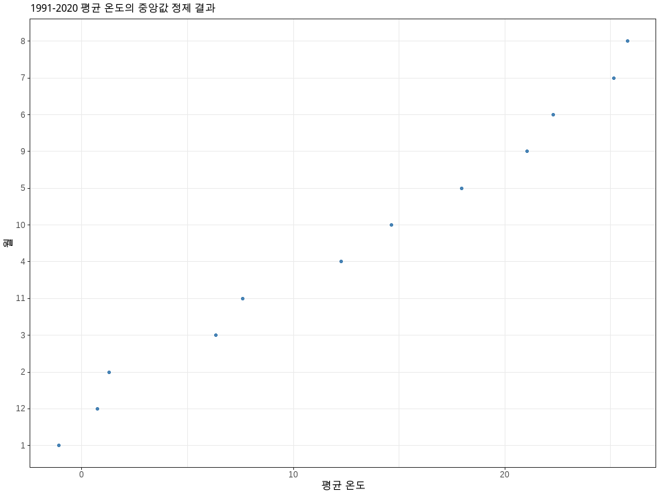

```r
mon <- c(1:12)
coleffect <- ma.fit$overall + ma.fit$col
check.c <- data.frame(mon, coleffect)
check.c %>%
  ggplot(aes(reorder(mon, coleffect), coleffect)) +
  geom_point(color = sbl) +
  geom_vline(xintercept = ma.fit$overall, color = ldg,) +
  labs(x = "월",
       y = "평균 온도",
       subtitle = "1991-2020 평균 온도의 중앙값 정제 결과"
  ) +
  coord_flip() +
  theme_bw()
```

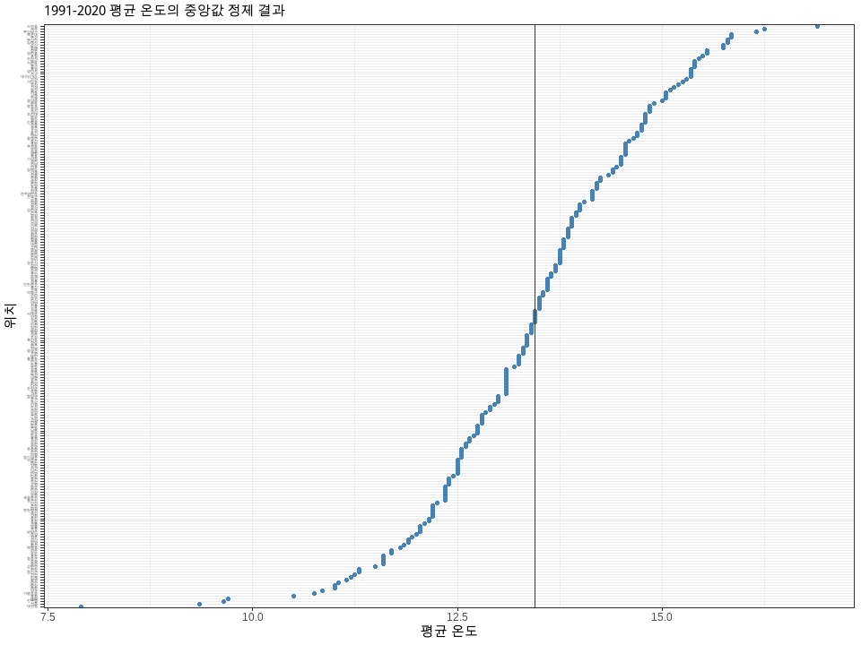

```r
loc <- row.names(atemp)
roweffect <- ma.fit$overall + ma.fit$row
check.r <- data.frame(loc, roweffect)
check.r %>%
  ggplot(aes(reorder(loc, roweffect), roweffect)) +
  geom_point(color = sbl) +
  geom_hline(yintercept = ma.fit$overall, color = ldg) +
  coord_flip() +
  labs(x = "위치",
       y = "평균 온도",
       subtitle = "1991-2020 평균 온도의 중앙값 정제 결과"
       ) +
  theme_bw() +
  theme(axis.text.y = element_text(size = 3))
```

가법 모형 적합 후의 잔차의 패턴을 고찰해 보면 다음과 같다.

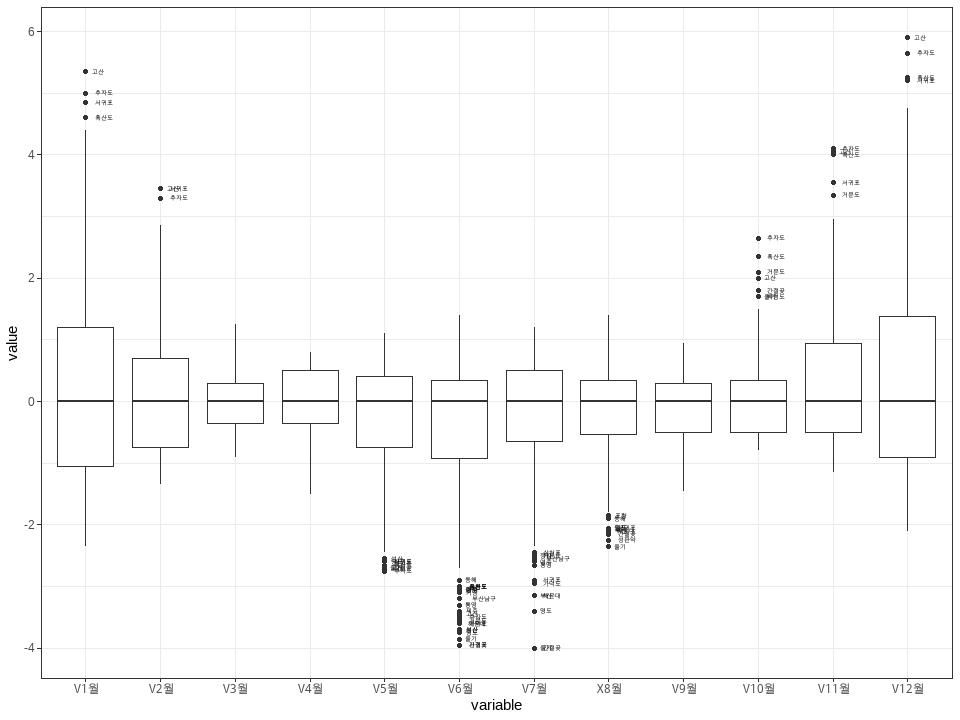

```r
res <- as.data.frame(ma.fit$residuals)

res %>%
  mutate(location = row.names(res)) %>%
  melt() %>%
  group_by(variable) %>%
  mutate(outlier = ifelse(is_outlier(value),
                          location,
                          as.character(NA))
         ) %>%
  ggplot(aes(x = variable, y = value)) +
  geom_boxplot() +
  geom_text(aes(label = outlier),
            size = 1.5,
            na.rm = T,
            hjust = -0.5
  ) +
  theme_bw()
```

- 잔차에서 이상점으로 진단된 행과 열의 값만 선택하여 heatmap 그리면 다음과 같다.

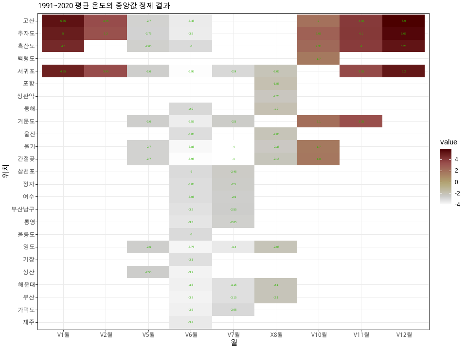

```r
res %>% #데이터 정리
  mutate(location = row.names(res)) %>%
  melt() %>%
  group_by(variable) %>%
  mutate(outlier = ifelse(is_outlier(value),
                          location,
                          as.character(NA))
  ) %>%
  dplyr::filter(outlier != "NA") %>% #이상점으로 진단된 값 추출

  #히트맵 그리기
  ggplot(aes(x = variable,
             y = fct_reorder(location, value),
             fill = value)) +
  geom_tile() +
  geom_text(aes(label = value),
            color = ngr,
            size = 1.5
            ) +
  labs(x = "월",
       y = "위치",
       subtitle = "1991~2020 평균 온도의 중앙값 정제 결과"
       ) +
  theme_bw() +
  scico::scale_fill_scico(palette = "bilbao")
```

- 현재의 가법 모형의 타당성을 확인하기 위하여 비교값을 계산한다.

- 계산 함수 적용 종류
  - **base::outer(x, y, fun = “*” …)**`: c(dim(x), dim(y))의 배열 생성하는 함수
  - **base::with(data, R expression)**: data 내의 변수 간 연산 결과 저장하는 함수
- cv: 비교 값

```r
cv <- with(ma.fit,
           outer(row, col, "*") / overall
      )
head(cv)
```

```
##               V1월        V2월        V3월         V4월        V5월        V6월
## 속초   -0.05408922 -0.04516729 -0.02639405 -0.004460967  0.01672862  0.03289963
## 철원    2.48810409  2.07769517  1.21412639  0.205204461 -0.76951673 -1.51338290
## 동두천  1.18996283  0.99368030  0.58066914  0.098141264 -0.36802974 -0.72379182
## 파주    1.89312268  1.58085502  0.92379182  0.156133829 -0.58550186 -1.15148699
## 대관령  6.00390335  5.01356877  2.92973978  0.495167286 -1.85687732 -3.65185874
## 춘천    1.35223048  1.12918216  0.65985130  0.111524164 -0.41821561 -0.82249071
##               V7월        X8월        V9월        V10월       V11월      V12월
## 속초    0.04349442  0.04591078  0.02825279  0.004460967 -0.02174721 -0.0472119
## 철원   -2.00074349 -2.11189591 -1.29962825 -0.205204461  1.00037175  2.1717472
## 동두천 -0.95687732 -1.01003717 -0.62156134 -0.098141264  0.47843866  1.0386617
## 파주   -1.52230483 -1.60687732 -0.98884758 -0.156133829  0.76115242  1.6524164
## 대관령 -4.82788104 -5.09609665 -3.13605948 -0.495167286  2.41394052  5.2405204
## 춘천   -1.08736059 -1.14776952 -0.70631970 -0.111524164  0.54368030  1.1802974
```

```r
df <- data.frame(loc = row.names(atemp),
                 cv = as.vector(cv),
                 res = as.vector(ma.fit$residuals)
                 )
head(df)
```

```
##      loc          cv   res
## 1   속초 -0.05408922  1.15
## 2   철원  2.48810409 -2.30
## 3 동두천  1.18996283 -1.60
## 4   파주  1.89312268 -1.75
## 5 대관령  6.00390335 -0.25
## 6   춘천  1.35223048 -1.75
```

- 산점도
  - (cv, residuals)에서 음(-)의 선형 관계가 있어 보이므로, 저항선을 통하여 기울기를 추정한다.

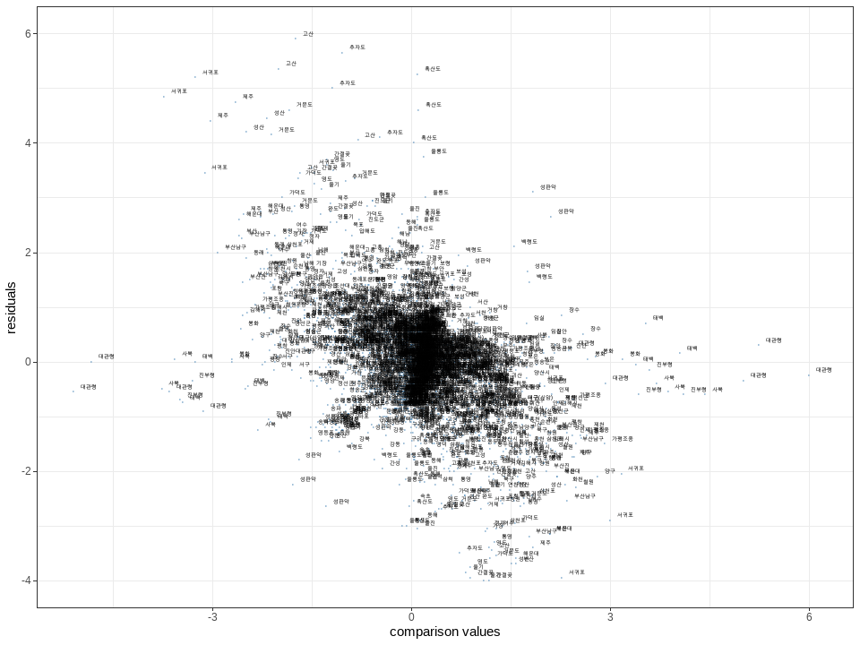

```r
df %>%
  ggplot(aes(cv, res, label = loc)) +
  geom_point(color = sbl, size = 0.5, alpha = 0.3) +
  geom_text(size = 1.5, hjust = 0, nudge_y = 0.1, nudge_x = 0.1) +
  labs(x = "comparison values",
       y = "residuals"
       ) +
  theme_bw()
```

- 기울기가 -0.49이므로 반영하여 패턴을 확인한다./
  - 수정된 잔차(adjusted residuals)에는 선형 패턴이 존재하지 않는다.

```r
round(rline(res ~ cv, df)$b, 2)
```

```
## [1] -0.49
```

- 최종적으로 적합된 잔차 확인

```r
out <- data.frame(iteration = NULL, slope = NULL, intercept = NULL)

iter.limit <- 10
for(iterations in 1:iter.limit){
  rfit <- rline(res ~ cv, df, iter = iterations)
  out <- rbind(out,
               data.frame(iteration = iterations,
                          slope = rfit$b,
                          intercept = rfit$a)
               )
}
```

- 7번 째 반복 적합 이후 절편과 기울기 수렴한다.
  - iteration을 7로하여 최종 저항선 추정 진행

```r
out
```

```
##    iteration      slope  intercept
## 1          1 -0.4936988 0.01773726
## 2          2 -0.4879199 0.01550707
## 3          3 -0.4868740 0.01575627
## 4          4 -0.4868181 0.01585234
## 5          5 -0.4868151 0.01585637
## 6          6 -0.4868149 0.01585659
## 7          7 -0.4868149 0.01585660
## 8          8 -0.4868149 0.01585660
## 9          9 -0.4868149 0.01585660
## 10        10 -0.4868149 0.01585660
```

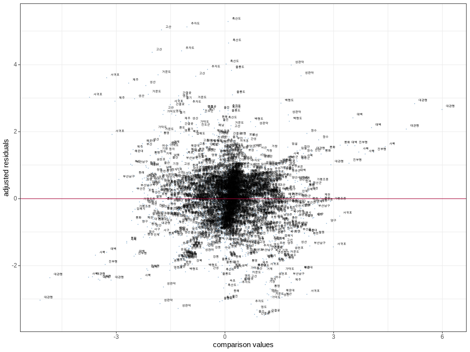

```r
final <- rline(res ~ cv, df, iter = 7)
df$adres <- final$residual
#최종 적합 산점도
df %>%
  ggplot(aes(cv, adres, label = loc)) +
  geom_point(color = sbl, size = 0.5, alpha = 0.3) +
  geom_text(size = 1.5, hjust = 0, nudge_y = 0.1, nudge_x = 0.1) +
  geom_hline(yintercept =0,
             color = lre) +
  labs(x = "comparison values",
       y = "adjusted residuals"
       ) +
  theme_bw()
```

## 9.3. 올림픽 수영 기록(swimming.csv)을 이용한 데이터 분석

10번의 하계 올림픽에서 여자 자유형 100, 200, 400, 800m 우승자들의 기록(초)로 각 연도별 그리고 시합의 거리별로 정리된 2원 데이터 표 `swimming.csv` 데이터를 활용하여 중앙값 정제 관련 실습을 진행한다.

```r
#`swimming` 데이터 관련 실습
#데이터 로드
swim <- read_csv(paste0(data_path, "swimming.csv"), show_col_types = FALSE)
str(swim) #5개 변수
```

```
## spc_tbl_ [10 × 5] (S3: spec_tbl_df/tbl_df/tbl/data.frame)
##  $ year: num [1:10] 1968 1972 1976 1980 1984 ...
##  $ v100: num [1:10] 60 58.6 55.6 54.8 55.9 ...
##  $ v200: num [1:10] 130 124 119 118 119 ...
##  $ v400: num [1:10] 272 259 250 249 247 ...
##  $ v800: num [1:10] 564 534 517 509 505 ...
##  - attr(*, "spec")=
##   .. cols(
##   ..   year = col_double(),
##   ..   v100 = col_double(),
##   ..   v200 = col_double(),
##   ..   v400 = col_double(),
##   ..   v800 = col_double()
##   .. )
##  - attr(*, "problems")=<externalptr>
```

```r
#결측값 개수 확인
sum(is.na(swim)) #0
```

```
## [1] 0
```

```r
#변수별 결측값 수 확인 사용자 함수 - na_count()
na_count(swim) #모두 0
```

```
## year v100 v200 v400 v800
##    0    0    0    0    0
```

```r
#데이터 구조 정리
#숫자형으로 저장된 행렬
record <- data.frame(swim[, -1]) #1열 제거
record
```

```
##     v100   v200   v400   v800
## 1  60.00 130.50 271.80 564.00
## 2  58.59 123.56 259.44 533.68
## 3  55.65 119.26 249.89 517.14
## 4  54.79 118.33 248.76 508.90
## 5  55.92 119.23 247.10 504.95
## 6  54.93 117.65 243.85 500.20
## 7  54.65 117.90 247.18 505.52
## 8  54.50 118.16 247.25 507.89
## 9  53.83 118.24 245.80 499.67
## 10 53.84 118.03 245.34 504.54
```

```r
row.names(record) <- swim$year #행이름 변경
record
```

```
##       v100   v200   v400   v800
## 1968 60.00 130.50 271.80 564.00
## 1972 58.59 123.56 259.44 533.68
## 1976 55.65 119.26 249.89 517.14
## 1980 54.79 118.33 248.76 508.90
## 1984 55.92 119.23 247.10 504.95
## 1988 54.93 117.65 243.85 500.20
## 1992 54.65 117.90 247.18 505.52
## 1996 54.50 118.16 247.25 507.89
## 2000 53.83 118.24 245.80 499.67
## 2004 53.84 118.03 245.34 504.54
```

```r
#중앙값 정제 - stats::medpolish 사용
sa.fit <- medpolish(record, 10) #medpolish(data, maxiter = n)
```

```
## Final: 135.86
```

```r
#Final: 135.86

#공통효과
sa.fit$overall #182.935
```

```
## [1] 182.935
```

```r
#행효과
head(sa.fit$row, 5)
```

```
##   1968   1972   1976   1980   1984
## 18.215  8.565  1.640  0.610  0.230
```

```r
#열효과
head(sa.fit$col, 5)
```

```
##      v100      v200      v400      v800
## -128.1975  -64.5925   64.5925  324.0825
```

```r
#행효과 범위
range(sa.fit$row) #-2.185 ~ 18.215
```

```
## [1] -2.185 18.215
```

```r
#열효과 범위
range(sa.fit$col)#-128.1975 ~ 324.0825
```

```
## [1] -128.1975  324.0825
```

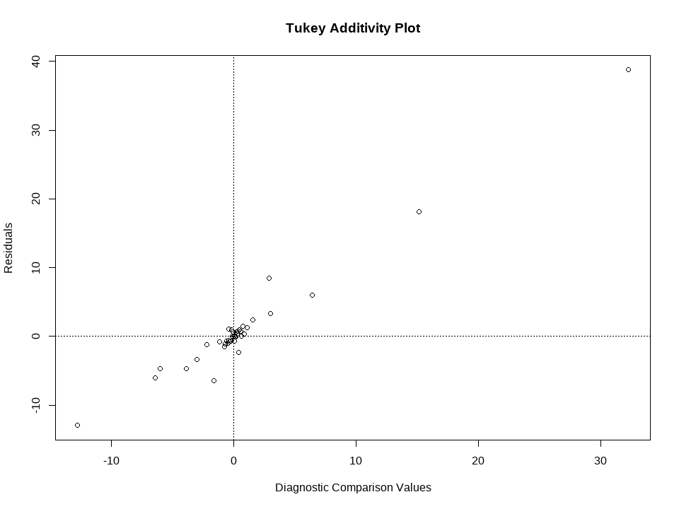

```r
#잔차와 비교값 그림
plot(sa.fit)
```

- 해석: 잔차의 값이 cv에 따라 증가하는 패턴, 양의 선형관계를 보인다. 즉, 이는 가법 모형보다 승법 모형이 적절하다는 의미이다.

```r
#적합선 기울기
res <- as.data.frame(sa.fit$residuals)
#비교값
cv <- with(sa.fit,
           outer(row, col, "*") / overall
           )
df <- data.frame(loc = row.names(record),
                 cv = as.vector(cv),
                 res = as.vector(sa.fit$residuals)
                 )
#기울기(k) 구하기
rline(res ~ cv, df)$b #1.104882
```

```
## [1] 1.104882
```

- 해석: $k=1.1$ 이므로 $p=1-k=1-1.1\approx 0$ 0일 때 멱승 변환은 log 변환이다. 데이터를 변호나하여 가법 모형을 재적합한다.

```r
lrecord <- log(record)
lrecord
```

```
##          v100     v200     v400     v800
## 1968 4.094345 4.871373 5.605067 6.335054
## 1972 4.070564 4.816727 5.558525 6.279796
## 1976 4.019082 4.781306 5.521021 6.248314
## 1980 4.003508 4.773477 5.516489 6.232252
## 1984 4.023922 4.781054 5.509793 6.224459
## 1988 4.006060 4.767714 5.496553 6.215008
## 1992 4.000949 4.769837 5.510117 6.225588
## 1996 3.998201 4.772040 5.510400 6.230265
## 2000 3.985831 4.772716 5.504518 6.213948
## 2004 3.986017 4.770939 5.502645 6.223647
```

```r
ta.fit <- medpolish(lrecord, 10) #Final: 0.1973325
```

```
## Final: 0.1973325
```

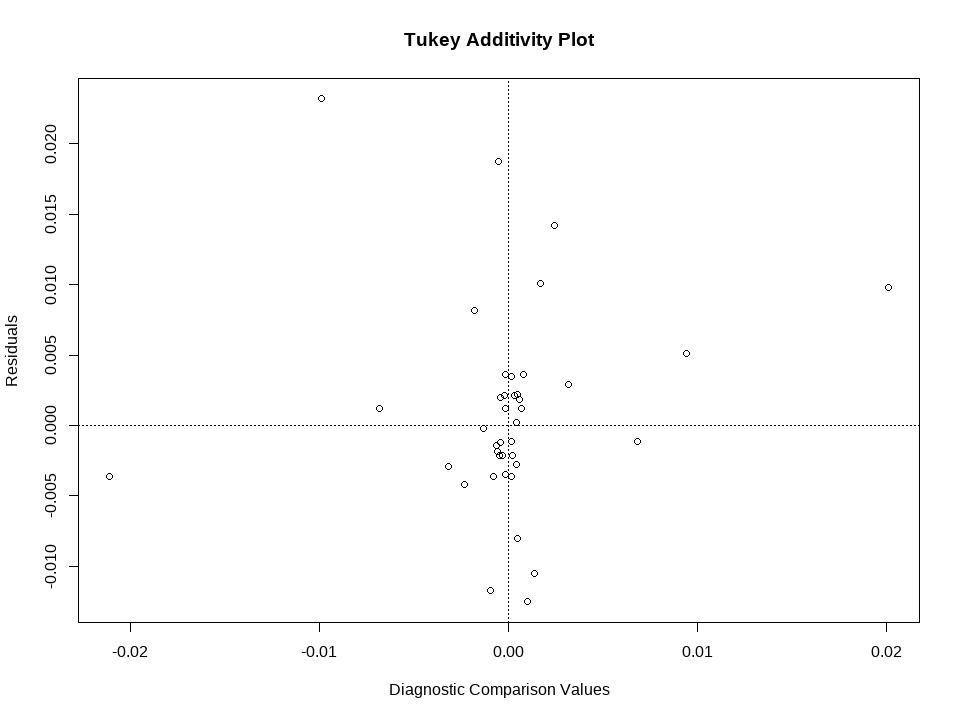

```r
plot(ta.fit)
```

- 해석: 잔차의 값이 cv에 대한 특정 관계가 존재하지 않는다. 가법 모형이 적합하다고 할 수 있다.

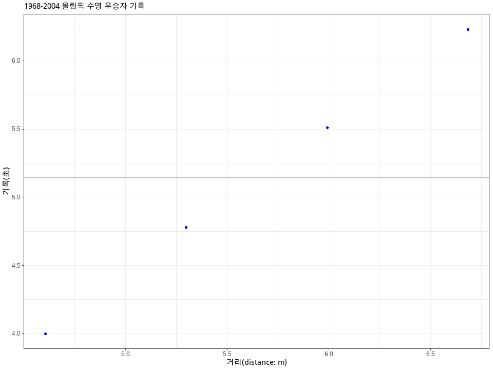

```r
distance <- log(c(100,200,400,800))
coleffect <- ta.fit$overall + ta.fit$col
check.c <- data.frame(distance, coleffect)
#추정 열효과 시각화
check.c %>%
  ggplot(aes(distance, round(coleffect, 2))) +
  geom_point(color = "blue") +
  geom_hline(yintercept = ta.fit$overall, color = "gray") +
  labs(x = "거리(distance: m)",
       y = "기록(초)",
       subtitle = "1968-2004 올림픽 수영 우승자 기록"
       ) +
  theme_bw()
```

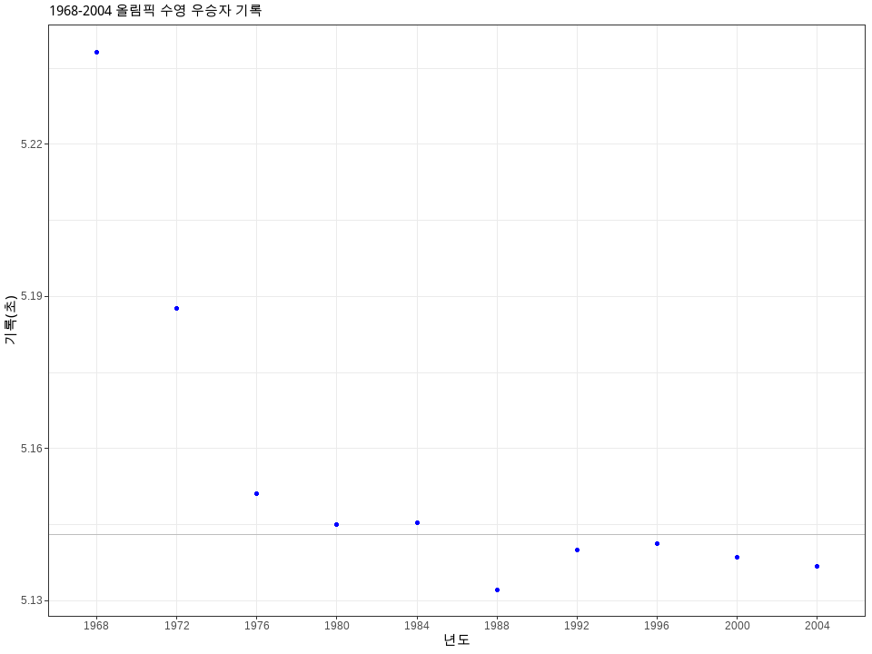

```r
year <- row.names(lrecord)
roweffect <- ta.fit$overall + ta.fit$row
check.r <- data.frame(year, roweffect)
check.r %>%
  ggplot(aes(year, roweffect)) +
  geom_point(color = "blue") +
  geom_hline(yintercept = ta.fit$overall, color = "gray") +
  labs(x = "년도",
       y = "기록(초)",
       subtitle = "1968-2004 올림픽 수영 우승자 기록"
       ) +
  theme_bw()
```

- 시간에 대한 행(연도) 효과를 비교하기 위해서 ratio(비)를 고려해야 한다. 기록된 최초년도 1968년과 비교했을 때 기록이 얼마나 개선되고 있는지를 파악.

```r
#행효과 비교 해석
row.origin <- as.vector(exp(ta.fit$row))
reffect.origin <- row.origin/row.origin[1]
round(reffect.origin, 2)
```

```
##  [1] 1.00 0.95 0.92 0.91 0.91 0.90 0.91 0.91 0.91 0.90
```

- 해석: 연도에 대한 해석은 마지막 기록 연도인 2004년은 1968년과 비교했을 때 약 10%가 감소되었다. 즉, 10%가 개선되었다.

```r
#열효과 비교 해석
col.origin <- as.vector(exp(ta.fit$col))
ceffect.origin <- col.origin/col.origin[1]
round(ceffect.origin, 2)
```

```
## [1] 1.00 2.16 4.52 9.27
```

- 해석: 거리에 대한 해석은 100m를 기준으로 200, 400, 800m로 올라갈수록 2.16배, 4.52배, 9.27배의 시간이 더 소요된다. 장거리로 갈수록 피로도가 높아가기 때문으로 보인다.